# Statistical Methods Final Project

Finally, the Center (mean) is ~1.740 and the Spread (standard deviation) is ~0.717 for the quantitative variable of screen time before sleep

b)Create bar graph and relative frequency table for the two categorical variables.

#Categorical Variable 1:**gender**

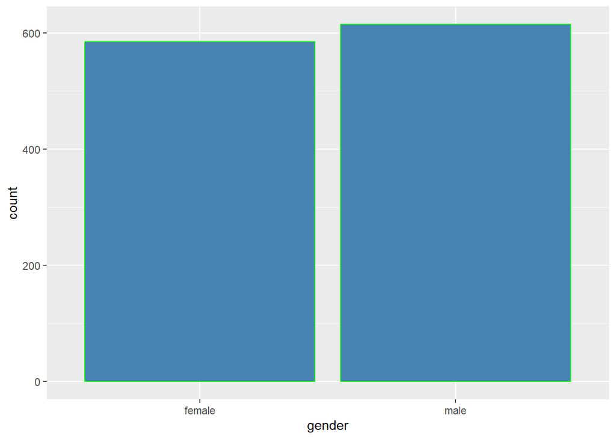

```r
#Bar Graph of Gender
ggplot(DATA, aes(x = gender)) +
  geom_bar(fill = "steelblue", color = "green")
```

```r
#Relative Frequency Table for Gender
DATA %>%
  count(gender, name = "freq") %>%
  mutate(rel_freq = freq/sum(freq))
```

| gender | freq | rel_freq |
| --- | --- | --- |
| female | 585 | 0.4875 |
| male | 615 | 0.5125 |

#Categorical variable 2: **platform_usage**

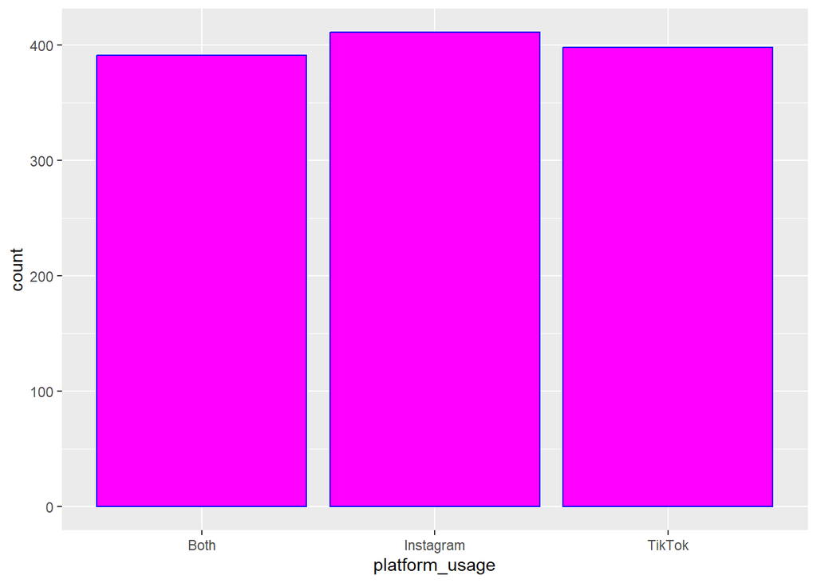

```r
#Bar Graph of Platform Usage
ggplot(DATA, aes(x = platform_usage)) + geom_bar(fill = "magenta", color  = "blue")
```

```r
#Relative Frequency Table for Platform Usage:
DATA %>%
  count(platform_usage, name = "freq") %>%
  mutate(rel_freq = freq/sum(freq))
```

| platform_usage | freq | rel_freq |
| --- | --- | --- |
| Both | 391 | 0.3258333 |
| Instagram | 411 | 0.3425000 |
| TikTok | 398 | 0.3316667 |

## 8 ————————————————————-

## 9 Heading 4

## 10 ————————————————————-

#Section 4.0 a) Population is all teenagers b) Sample is 1200 teenagers

#Section 4.1 a) The variable is daily hours of sleep which is Quantitative b) Parameter is mean number of hours asleep c) Independent d) Point Estimate is 6.449417 Lower = 6.341972 and Upper = 6.556862

```r
DATA %>% summarise(DATA_mean = mean(sleep_hours), DATA_sd = sd(sleep_hours))
```

| DATA_mean | DATA_sd |
| --- | --- |
| 6.449417 | 1.442677 |

```r
t.test(x = DATA$sleep_hours, conf.level = 0.99)
```

```
##
##  One Sample t-test
##
## data:  DATA$sleep_hours
## t = 154.86, df = 1199, p-value < 2.2e-16
## alternative hypothesis: true mean is not equal to 0
## 99 percent confidence interval:
##  6.341971 6.556862
## sample estimates:
## mean of x
##  6.449417
```

5. It is recommended by doctors and health professionals that everyone should sleep for 8 hours a night to get a good nights rest. Lack of sleep can lead to multiple mental problems which can affect anyone. Do these results show a average of sleep less then 8 hours a night with a 0.05 significance level?

```r
t0 <- (6.449417 - 8)/(1.442677/sqrt(1200))
t0
```

```
## [1] -37.23201
```

```r
pt(q = t0, df = 1200 - 1 )
```

```
## [1] 1.432134e-202
```

There is sufficient evidence at $\alpha$ = 0.05 to conclude that the mean hours of sleep each night for teenagers is less then the recommended 8

```r
DATA %>% count(gender)
```

| gender | n |
| --- | --- |
| female | 585 |
| male | 615 |

```r
585/1200
```

```
## [1] 0.4875
```

```r
p_hat <- 0.4875
s_hat <- sqrt(0.4875*(1-0.4875)/1200)
z_alpha_2 <- 1 - qnorm((1-0.98)/2, mean = 0, sd = 1)

#Lower Bound
p_hat - z_alpha_2 * s_hat
```

```
## [1] 0.4395033
```

```r
#Upper Bound
p_hat + z_alpha_2 * s_hat
```

```
## [1] 0.5354967
```

5. The gender background of subjects can show trends just as much as any other qualitative variables. At 0.05 significance level, test the hypothesis that the proportion of female teenagers is less then 50%.

```r
prop.test(x = 585, n = 1200, p = 0.50, alternative = "less", correct = F)
```

```
##
##  1-sample proportions test without continuity correction
##
## data:  585 out of 1200, null probability 0.5
## X-squared = 0.75, df = 1, p-value = 0.1932
## alternative hypothesis: true p is less than 0.5
## 95 percent confidence interval:
##  0.0000000 0.5112354
## sample estimates:
##      p
## 0.4875
```

Since p-value = 0.1932 > 0.05 = $\aplha$, we can fail to reject $H_0$. There is insufficient evidence at $\aplha$ = 0.05 to conclude that the proportion of teenagers that were female was less the 50%

## 11 ————————————————————-

## 12 Heading 5

## 13 ————————————————————-

Quantitative Variables: **sleep_hours** Test female vs male sleep hours

#Section 5.1

We want to test if the time asleep for males is largely different time spent asleep for females. We will be testing this at the 95% confidence level with $\mu_1 - \mu_2$ representing the difference. from male sleeping to female sleeping. a) Population 1 = all male teenagers Population 2 = all female teenagers b) Sample 1 = 615 male teenagers Sample 2 = 585 female teenagers c) Time asleep and gender, Time Asleep is Quantitative while Gender is Qualitative d) Parameter 1 = $\mu_1$ = mean time asleep for males Parameter 2 = $\mu_2$ = mean time asleep for females e) They are both independent

```r
DATA_male <- DATA %>% filter(gender == "male")
DATA_female <- DATA %>% filter(gender == "female")

t.test(x = DATA_male$sleep_hours, y = DATA_female$sleep_hours, alternative = "two.sided", conf.level = 0.95)
```

```
##
##  Welch Two Sample t-test
##
## data:  DATA_male$sleep_hours and DATA_female$sleep_hours
## t = -1.1018, df = 1197.9, p-value = 0.2708
## alternative hypothesis: true difference in means is not equal to 0
## 95 percent confidence interval:
##  -0.25497435  0.07158473
## sample estimates:
## mean of x mean of y
##  6.404715  6.496410
```

## 14 ————————————————————-

## 15 Heading 6

## 16 ————————————————————-

Use two quantitative variables to show if there is a linear relationship between them.

1. What are the variables? What type of variables are they?

Quantitative Variable 1: **sleep_hours** Quantitative Variable 2: **screen_time_before_sleep**

2. Run a hypothesis test to test your hypothesis.

#Not sure if it wants me to test the original hypothesis from section 2.1 or the new hypothesis made specifically for this section? The instructions for the project do not make this clear. As such, might be safe to test both.

Hypothesis 1: Is there a linear relationship between the screen_time_before_sleep and the number of sleep hours gotten? $H_0: \beta_1 = 0$ $H_A: \beta_1 \neq 0$

```r
model = lm(screen_time_before_sleep ~ sleep_hours, data = DATA)

#coef(model)
summary(model)
```

```
##
## Call:
## lm(formula = screen_time_before_sleep ~ sleep_hours, data = DATA)
##
## Residuals:
##      Min       1Q   Median       3Q      Max
## -1.24923 -0.63144  0.04772  0.64759  1.27060
##
## Coefficients:
##             Estimate Std. Error t value Pr(>|t|)
## (Intercept) 1.707542   0.094843  18.004   <2e-16 ***
## sleep_hours 0.005084   0.014351   0.354    0.723
## ---
## Signif. codes:  0 '***' 0.001 '**' 0.01 '*' 0.05 '.' 0.1 ' ' 1
##
## Residual standard error: 0.7169 on 1198 degrees of freedom
## Multiple R-squared:  0.0001048,  Adjusted R-squared:  -0.0007299
## F-statistic: 0.1255 on 1 and 1198 DF,  p-value: 0.7232
```

P-value: 0.7232

Decision: The P-value of 0.7232 is greater than alpha level of $\alpha = 0.05$. Also, the Adjusted R-squared is near zero, showing only a little of variance is a result of the dependent variable. Thus we fail to reject the null hypothesis

Conclusion: Given the P-value of 0.7232 is greater than alpha level $\alpha = 0.05$, we fail to reject the null hypothesis as there is insufficient evidence that there is a linear relationship between the quantitative variables of screen time before sleep and sleep hours obtained.

#Does the linear relationship vary by gender? Hypothesis 2: Is there a linear relationship between the screen_time_before_sleep and the number of sleep hours gotten for females only?

$H_0: \beta_f = 0$ $H_A: \beta_f \neq 0$

```r
#Does it vary by gender?
fem <- DATA %>% filter(gender == "female")
model_fem = lm(screen_time_before_sleep ~ sleep_hours, data = fem)
summary(model_fem)
```

```
##
## Call:
## lm(formula = screen_time_before_sleep ~ sleep_hours, data = fem)
##
## Residuals:
##      Min       1Q   Median       3Q      Max
## -1.31030 -0.57605 -0.01358  0.59776  1.28239
##
## Coefficients:
##             Estimate Std. Error t value Pr(>|t|)
## (Intercept)  1.89091    0.13786  13.716   <2e-16 ***
## sleep_hours -0.02015    0.02074  -0.972    0.332
## ---
## Signif. codes:  0 '***' 0.001 '**' 0.01 '*' 0.05 '.' 0.1 ' ' 1
##
## Residual standard error: 0.707 on 583 degrees of freedom
## Multiple R-squared:  0.001617,   Adjusted R-squared:  -9.56e-05
## F-statistic: 0.9442 on 1 and 583 DF,  p-value: 0.3316
```

P-value: 0.3316

Conclusion: P-value of 0.3316 is greater than alpha level $\alpha = 0.05$. Therefore, we fail to reject the null hypothesis as there is insufficient evidence that there is a linear relationship between the quantitative variables of screen time before sleep and sleep hours obtained for only females.

Hypothesis 3: Is there a linear relationship between the screen_time_before_sleep and the number of sleep hours gotten for males only?

$H_0: \beta_m = 0$ $H_A: \beta_m \neq 0$

```r
male <- DATA %>% filter(gender == "male")
model_male = lm(screen_time_before_sleep ~ sleep_hours, data = male)
summary(model_male)
```

```
##
## Call:
## lm(formula = screen_time_before_sleep ~ sleep_hours, data = male)
##
## Residuals:
##      Min       1Q   Median       3Q      Max
## -1.26366 -0.63468  0.02317  0.61539  1.33383
##
## Coefficients:
##             Estimate Std. Error t value Pr(>|t|)
## (Intercept)  1.55287    0.13068  11.883   <2e-16 ***
## sleep_hours  0.02635    0.01989   1.325    0.186
## ---
## Signif. codes:  0 '***' 0.001 '**' 0.01 '*' 0.05 '.' 0.1 ' ' 1
##
## Residual standard error: 0.7253 on 613 degrees of freedom
## Multiple R-squared:  0.002856,   Adjusted R-squared:  0.001229
## F-statistic: 1.756 on 1 and 613 DF,  p-value: 0.1857
```

P-value: 0.1857

Conclusion: The P-value of 0.1857 is greater than alpha level $\alpha = 0.05$. Thus, we fail to reject the null hypothesis as there is insufficient evidence that there is a linear relationship between the quantitative variables of screen time before sleep and sleep hours obtained for males only.

Section 6 Discussion:

## 17 ————————————————————-

## 18 Heading 7

## 19 ————————————————————-

#### 19.0.1 1. One sample confidence interval for the population proportion from the variable selected in Section 1.1.

Construct a 98% confidence interval for the proportion of teens who are female.

#### 19.0.2 2. One sample confidence interval for the population mean from the variable selected in Section 1.2.

Construct a 99% confidence interval for the mean sleep hours of teens.

Answer: We are 99% confident that the true mean sleep hours for teenagers is between 6.342 and 6.557 hours per night.

#### 19.0.3 3. Formulate a research question to conduct a one-sample proportion hypothesis test based on the variable from Section 1.1.

$H_0: p = 0.50$

$H_A: p < 0.50$

Answer: There is insufficient evidence at α = 0.05 to conclude that the proportion of female teenagers is less than 50%.

#### 19.0.4 4. Formulate a research question to conduct a one sample t test hypothesis test based on the variable in Section 1.2.

**Research Question:** Do teens get less than the recommended 8 hours of sleep?

$H_0: \mu = 8$

$H_A: \mu < 8$

Answer: There is sufficient evidence at α = 0.05 to conclude that teenagers sleep less than the CDC recommended 8 hours per night.

#### 19.0.5 5. Create a research question to do two sample mean (independent t test) hypothesis tests.

**Research Question:** Is there a difference in mean sleep hours between male and female teens?

$H_0: \mu_1 - \mu_2 = 0$ (no difference in mean sleep hours between males and females)

$H_A: \mu_1 - \mu_2 \neq 0$ (there is a difference in mean sleep hours between males and females)

Answer: There is insufficient evidence at α = 0.05 to conclude that there is a difference in mean sleep hours between male and female teenagers.

#### 19.0.6 6. Use two quantitative variables to show if there is a linear relationship between them.

**Research Question:** Is there a linear relationship between screen time before sleep and sleep hours?

$H_0: \beta_1 = 0$ $H_A: \beta_1 \neq 0$

Answer: There is insufficient evidence at α = 0.05 to conclude that there is a linear relationship between screen time before sleep and sleep hours.